# Emissions & Preferences

Martin Blasi, Jonas Wallstein & Carles Manchado

2022-11-28

# Emissions and Preferences

- CO2 emissions: Total and per sector (9) from NACE (Statistical classification of economic activities in the European Community) in tonnes of CO2 per capita
- Together with GDP per capita from OECD
- Preference parameters from Global Preference Survey, Falck et al. (2012)
- n=74 countries
- p=17 variables (subset with p=8)
- Methods: PCA & Clustering
- Goal: Hidden interesting patterns behind pollution behaviour and fundamental preference paramters

# Results

- PCAs deliver poor picture
- First two PCs only explain 46% of the variance
- Main reason: Correlation between preference paramters and emissions is not too great
- Clustering delivers four/five groups that sort of make sense

# Data description

Load the data

```r
load("C:/Users/blasi/OneDrive/Desktop/UPF Studies/multivariate data analysis/Class/Group project/1 LOCAL COPIES/gps/Emissions_and_Preferences.RData")
```

Subset

```r
library("dplyr")
df.empref1 =
  df.empref %>%
    select(-c(country))

rownames(df.empref1) <- df.empref1[,1]

df.empref2 =
  df.empref1 %>%
    select(-c(iso_code))

#subset of preferences and only TOTAL emissions
df.empref2sub =
    df.empref2 %>%
      select(-c(emissions.agriculture, emissions.buildings, emissions.extraction, emissions.manufacturing, emissions.maritime, emissions.oil.and.gas, emissions.power, emissions.transport ,emissions.waste))

head(df.empref2)
```

```
##     emissions.agriculture emissions.buildings emissions.extraction
## AFG             0.3957772          0.01834653         0.0000290277
## ARE             0.1974293          0.09429882         0.0120848500
## ARG             3.0072380          0.82088379         0.0024261781
## AUS             3.6778982          1.70121138         0.3252070990
## AUT             0.7876306          1.21605381         0.0073026959
## BGD             0.8178415          0.10906422         0.0004638914
##     emissions.manufacturing emissions.maritime emissions.oil.and.gas
## AFG              0.04680824        0.000000000            0.01343099
## ARE              8.32443673        0.013592979            7.52139145
## ARG              0.83803413        0.005313815            1.20629010
## AUS              1.76701220        0.029528531            5.07385329
## AUT              1.95156777        0.000000000            0.28491573
## BGD              0.15956953        0.005313833            0.04139945
##     emissions.power emissions.transport emissions.waste emissions.total
## AFG      0.09614189          0.06250490       0.1496082        0.782647
## ARE      8.55735663          4.84351907       0.7578662       30.321976
## ARG      1.08678439          0.98123929       0.3654634        8.313673
## AUS      7.06306539          4.52142924       0.5468426       24.706048
## AUT      1.37038994          2.36183581       0.3125281        8.292224
## BGD      0.25273783          0.07289708       0.5931894        2.052477
##            GDP    patience  risktaking   posrecip    negrecip    altruism
## AFG   516.7479 -0.20136012  0.12076426 0.28964090  0.25471246  0.16645546
## ARE 36284.5552 -0.09131865  0.08651500 0.07319601  0.22190480  0.15418167
## ARG  8620.0763 -0.22930798  0.04150317 0.15967931 -0.14045727  0.02734668
## AUS 52072.2518  0.65700376  0.13713655 0.06966002  0.02218975  0.15533145
## AUT 48105.6213  0.60828501 -0.06182915 0.16104659 -0.05541545 -0.03536313
## BGD  2270.3474  0.08113671 -0.19806775 0.15436757  0.11328817  0.90646327
##          trust
## AFG  0.3159644
## ARE  0.5071083
## ARG -0.2067333
## AUS  0.2989726
## AUT  0.1546281
## BGD -0.1733653
```

Scale and covariance matrix

```r
X <- as.matrix(df.empref2)

Xs <- scale(X)
R <- cov(Xs)
R
```

```
##                         emissions.agriculture emissions.buildings
## emissions.agriculture             1.000000000        0.2244541860
## emissions.buildings               0.224454186        1.0000000000
## emissions.extraction              0.259419263        0.1334652412
## emissions.manufacturing          -0.049935862        0.3332183489
## emissions.maritime                0.131890279        0.2143808720
## emissions.oil.and.gas             0.239584952        0.4252720275
## emissions.power                   0.073210157        0.4106578299
## emissions.transport               0.225662310        0.6606785741
## emissions.waste                   0.311471157       -0.0527567332
## emissions.total                   0.300043840        0.5902319248
## GDP                               0.151838188        0.6643868379
## patience                          0.133877008        0.5482954555
## risktaking                       -0.166392926       -0.0657320967
## posrecip                          0.005420612        0.1273438649
## negrecip                         -0.183969416        0.2148362222
## altruism                         -0.154207204        0.0006905576
## trust                             0.060043244        0.1696291597
##                         emissions.extraction emissions.manufacturing
## emissions.agriculture             0.25941926             -0.04993586
## emissions.buildings               0.13346524              0.33321835
## emissions.extraction              1.00000000              0.05724580
## emissions.manufacturing           0.05724580              1.00000000
## emissions.maritime               -0.03309901              0.08034816
## emissions.oil.and.gas             0.24974568              0.74136703
## emissions.power                   0.25083374              0.79634137
## emissions.transport               0.28750194              0.67270347
## emissions.waste                   0.13362469              0.23172902
## emissions.total                   0.27530563              0.84104364
## GDP                               0.17383953              0.39951208
## patience                          0.14812369              0.29333200
## risktaking                        0.07653729              0.09161681
## posrecip                          0.05773708              0.06683438
## negrecip                         -0.05291107              0.29013088
## altruism                          0.02734433              0.01602567
## trust                             0.10264080              0.40065831
##                         emissions.maritime emissions.oil.and.gas
## emissions.agriculture           0.13189028           0.239584952
## emissions.buildings             0.21438087           0.425272027
## emissions.extraction           -0.03309901           0.249745678
```

[output cut: 53 more lines]

```
## emissions.extraction     0.057737085 -0.052911070  0.0273443251  0.10264080
## emissions.manufacturing  0.066834375  0.290130875  0.0160256681  0.40065831
## emissions.maritime      -0.020634000  0.092852481 -0.1456979935 -0.02416590
## emissions.oil.and.gas    0.008942529  0.162557241  0.0589996519  0.36063873
## emissions.power         -0.046418076  0.310062054 -0.0797673159  0.26282904
## emissions.transport      0.085932728  0.277363510 -0.0173991080  0.34750280
## emissions.waste          0.128713375  0.003308089 -0.0160733294  0.26667135
## emissions.total          0.038473056  0.263252028 -0.0415975560  0.36979929
## GDP                      0.084587211  0.181705016 -0.0365026336  0.25453551
## patience                 0.023852252  0.252549778 -0.0117326968  0.19276983
## risktaking              -0.255154048  0.201806420 -0.0241074096 -0.07036452
## posrecip                 1.000000000 -0.149747294  0.7343291747  0.37449605
## negrecip                -0.149747294  1.000000000 -0.1319507560  0.16499077
## altruism                 0.734329175 -0.131950756  1.0000000000  0.26735742
## trust                    0.374496051  0.164990767  0.2673574231  1.00000000
```

# PCA

```r
l <- eigen(R)$values
V <- eigen(R)$vectors
Y <- Xs %*% V
# the portion of the variance that retains each PC
R2 = l / sum(l) *100
# accumulating this quantities:
cumsum( l / sum(l))
```

```
##  [1] 0.3397255 0.4609486 0.5624509 0.6516423 0.7269956 0.7835394 0.8282030
##  [8] 0.8692724 0.9059339 0.9359331 0.9531418 0.9675855 0.9799815 0.9888253
## [15] 0.9960671 1.0000000 1.0000000
```

```r
#automatically
library(ade4)
library(factoextra)
pca.empref = dudi.pca(df.empref2, scannf = FALSE)
pca.empref$eig
```

```
##  [1] 5.77533391 2.06079162 1.72553916 1.51625415 1.28100715 0.96124336
##  [7] 0.75928114 0.69818015 0.62324524 0.50998670 0.29254744 0.24554317
## [13] 0.21073161 0.15034512 0.12311155 0.06685854
```

```r
cumsum(pca.empref$eig)/sum(pca.empref$eig)
```

```
##  [1] 0.3397255 0.4609486 0.5624509 0.6516423 0.7269956 0.7835394 0.8282030
##  [8] 0.8692724 0.9059339 0.9359331 0.9531418 0.9675855 0.9799815 0.9888253
## [15] 0.9960671 1.0000000
```

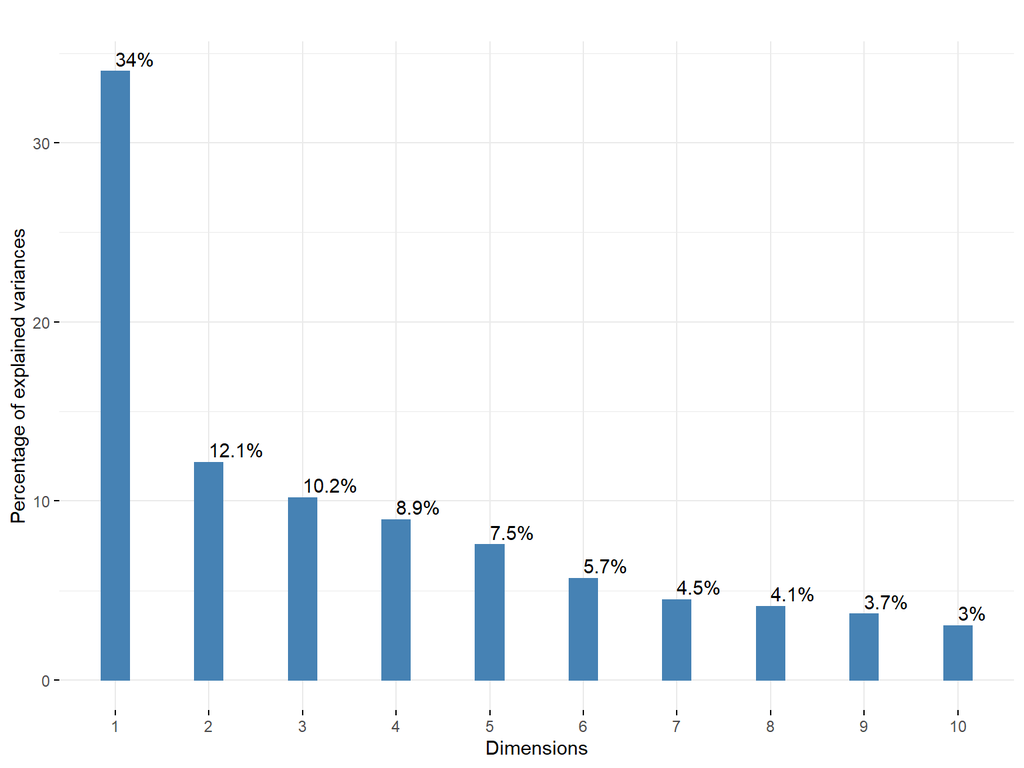

```r
fviz_eig(pca.empref, geom = "bar", bar_width = 0.3, addlabels=T) + ggtitle("")
```

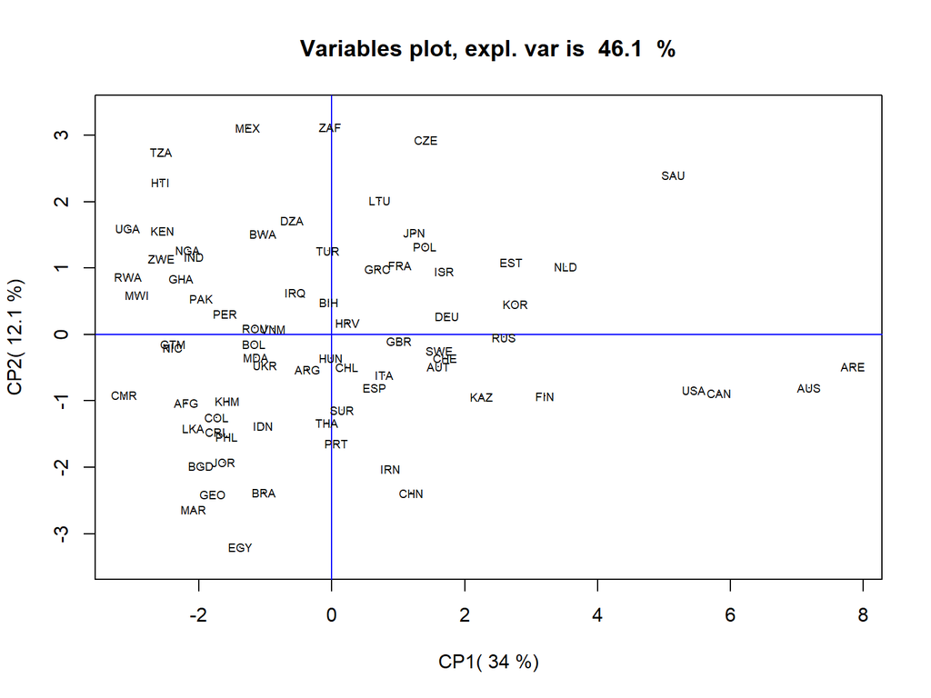

```r
#Plot
plot(Y[,1:2],
  type="n", # don't plot anything now
  asp = 1, # aspect ratio, very important!
  main=paste("Variables plot, expl. var is ",
               round(R2[1]+R2[2],1), " %"),
  xlab=paste("CP1(", round(R2[1],1), "%)"), # title x axis
  ylab=paste("CP2(", round(R2[2],1), "%)") # title y axis
)

# add the axis
abline(v=0, col="blue")
abline(h=0, col="blue")

# the dots and names
points(Y[,1:2], pch=".") # plot a dot per row
text(Y[,1:2],row.names(df.empref2),cex=0.6)
```

# SVD and Variables Plot

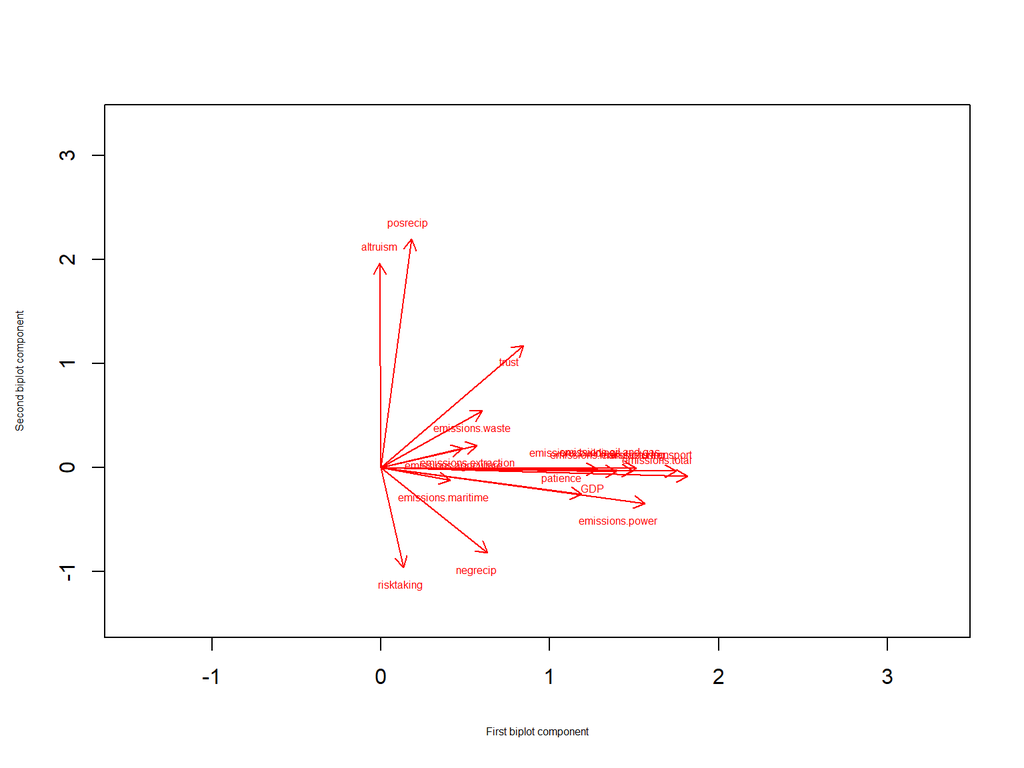

```r
#Carry out the Singular Value Decomposition
svd <- svd(Xs)


Utilde <- svd$u[,1:2] %*% sqrt(diag(svd$d[1:2]))
Vtilde <- svd$v[,1:2] %*% sqrt(diag(svd$d[1:2]))


nn <- paste(rownames(Xs))
xlim <- ylim <- range(c(range(1.5*Vtilde)))
plot(NULL,xlab='First biplot component',ylab='Second biplot component',xlim=xlim,ylim=ylim,cex.lab=0.5)
arrows(x0=0,y0=0,x1=Vtilde[,1],y1=Vtilde[,2],col='red', code=2, length=0.1)
text(.9*Vtilde[,1],Vtilde[,2],paste(colnames(Xs)),pos=c(1,3),col='red',cex=0.5)
```

Biplot

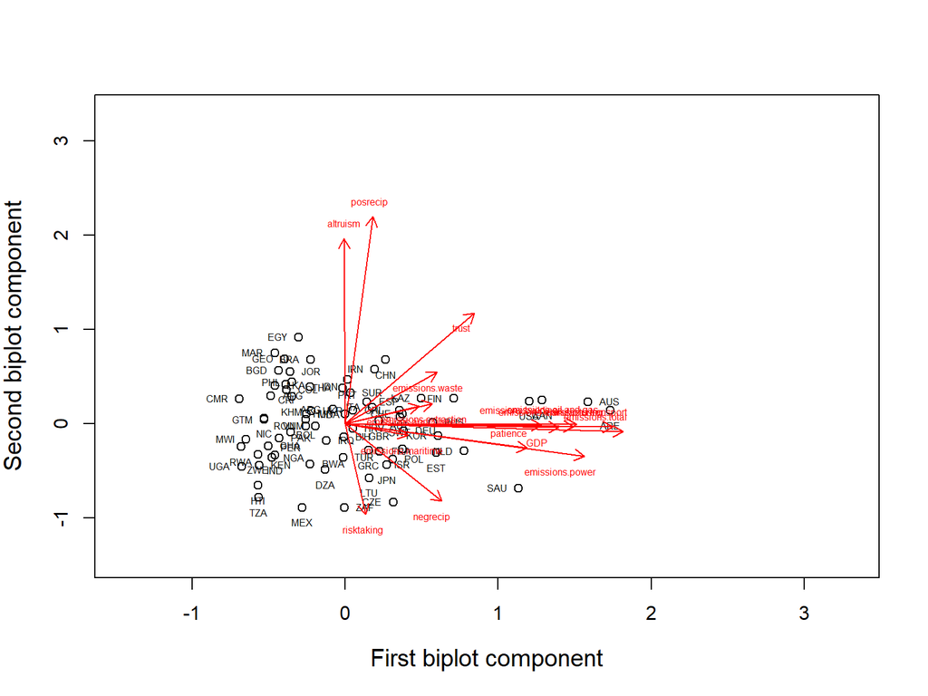

```r
nn <- paste(rownames(Xs))
xlim <- ylim <- range(c(range(Vtilde),range(1.5*Vtilde)))
plot(Utilde,xlab='First biplot component',ylab='Second biplot component',xlim=xlim,ylim=ylim,cex.lab=1.25)
text(Utilde[,1:2],nn,pos=c(4,1,2),cex=0.5)
arrows(x0=0,y0=0,x1=Vtilde[,1],y1=Vtilde[,2],col='red', code=2, length=0.1)
text(.9*Vtilde[,1],Vtilde[,2],paste(colnames(Xs)),pos=c(1,3),col='red',cex=0.5)
```

# Subset Analysis

Total emissions only

Scale and covariance matrix

```r
Xsub <- as.matrix(df.empref2sub)

Xssub <- scale(Xsub)
Rs <- cov(Xssub)
```

PCA

```r
ls <- eigen(Rs)$values
Vs <- eigen(Rs)$vectors
Ys <- Xssub %*% Vs
# the portion of the variance that retains each PC
R2s = ls / sum(ls) *100
# accumulating this quantities:
cumsum( ls / sum(ls))
```

```
## [1] 0.3168434 0.5679464 0.7020924 0.8159399 0.8961491 0.9555233 0.9828677
## [8] 1.0000000
```

```r
#automatically
library(ade4)
library(factoextra)
pca.emprefsub = dudi.pca(df.empref2sub, scannf = FALSE)
pca.emprefsub$eig
```

```
## [1] 2.5347472 2.0088238 1.0731681 0.9107800 0.6416738 0.4749931 0.2187559
## [8] 0.1370581
```

```r
cumsum(pca.emprefsub$eig)/sum(pca.emprefsub$eig)
```

```
## [1] 0.3168434 0.5679464 0.7020924 0.8159399 0.8961491 0.9555233 0.9828677
## [8] 1.0000000
```

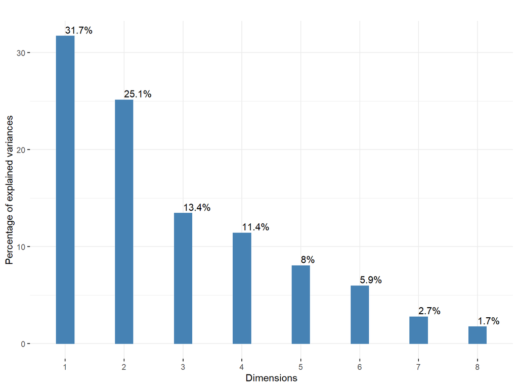

```r
fviz_eig(pca.emprefsub, geom = "bar", bar_width = 0.3, addlabels=T) + ggtitle("")
```

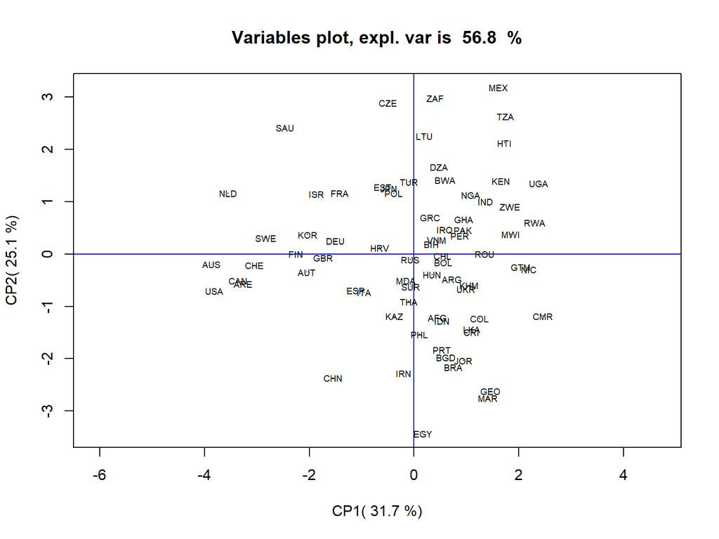

```r
#Plot
plot(Ys[,1:2],
  type="n", # don't plot anything now
  asp = 1, # aspect ratio, very important!
  main=paste("Variables plot, expl. var is ",
               round(R2s[1]+R2s[2],1), " %"),
  xlab=paste("CP1(", round(R2s[1],1), "%)"), # title x axis
  ylab=paste("CP2(", round(R2s[2],1), "%)") # title y axis
)

# add the axis
abline(v=0, col="blue")
abline(h=0, col="blue")

# the dots and names
points(Ys[,1:2], pch=".") # plot a dot per row
text(Ys[,1:2],row.names(df.empref2sub),cex=0.6)
```

# SVD and Variables Plot

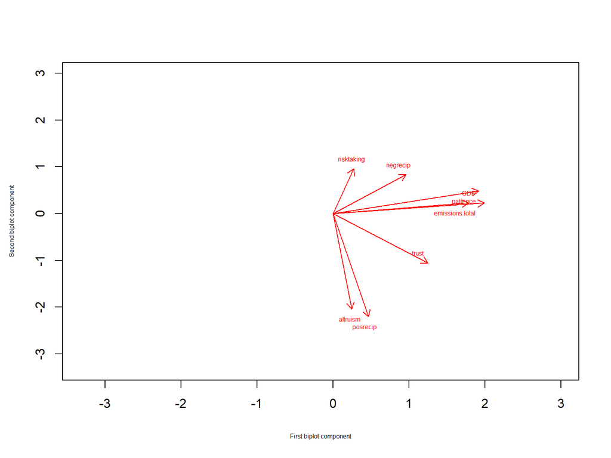

```r
#Carry out the Singular Value Decomposition
svdsub <- svd(Xssub)


Utildes <- svdsub$u[,1:2] %*% sqrt(diag(svdsub$d[1:2]))
Vtildes <- svdsub$v[,1:2] %*% sqrt(diag(svdsub$d[1:2]))


nn <- paste(rownames(Xssub))
xlim <- ylim <- range(c(range(1.5*Vtildes)))
plot(NULL,xlab='First biplot component',ylab='Second biplot component',xlim=xlim,ylim=ylim,cex.lab=0.5)
arrows(x0=0,y0=0,x1=Vtildes[,1],y1=Vtildes[,2],col='red', code=2, length=0.1)
text(.9*Vtildes[,1],Vtildes[,2],paste(colnames(Xssub)),pos=c(1,3),col='red',cex=0.5)
```

# Biplot

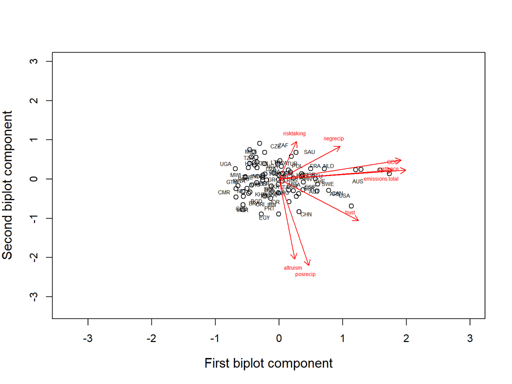

```r
nn <- paste(rownames(Xssub))
xlim <- ylim <- range(c(range(Vtildes),range(1.5*Vtildes)))
plot(Utilde,xlab='First biplot component',ylab='Second biplot component',xlim=xlim,ylim=ylim,cex.lab=1.25)
text(Utildes[,1:2],nn,pos=c(4,1,2),cex=0.5)
arrows(x0=0,y0=0,x1=Vtildes[,1],y1=Vtildes[,2],col='red', code=2, length=0.1)
text(.9*Vtildes[,1],Vtildes[,2],paste(colnames(Xssub)),pos=c(1,3),col='red',cex=0.5)
```

# Clustering

Distances

```r
d_euclidean <- dist(Xs)
d_manhattan <- dist(Xs, method="manhattan")

# S^(-1/2)
Sinvsqrt = V%*%diag(1/sqrt(l))

# X in mahalanobis space
Xinvsqrt = Xs%*%Sinvsqrt

d_mahalanobis <- as.dist(dist(Xinvsqrt))
```

Hierarchical Clustering Eucledian

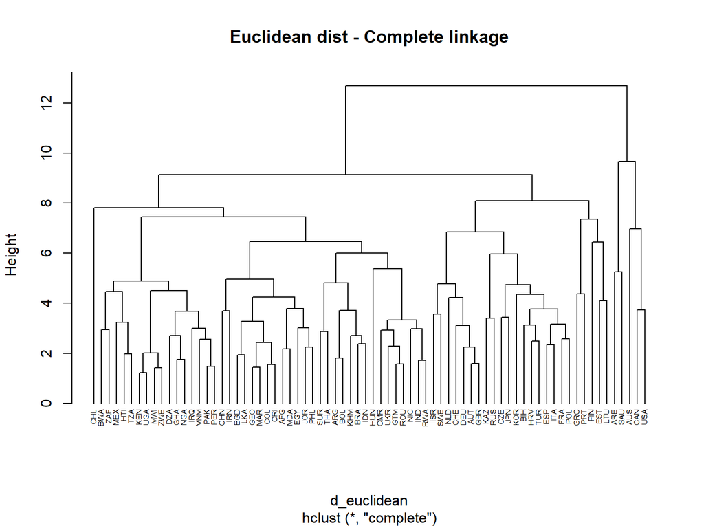

```r
hc <- hclust(d_euclidean)
plot(hc ,hang = -1, main="Euclidean dist - Complete linkage", cex=0.5)
```

Manhattan

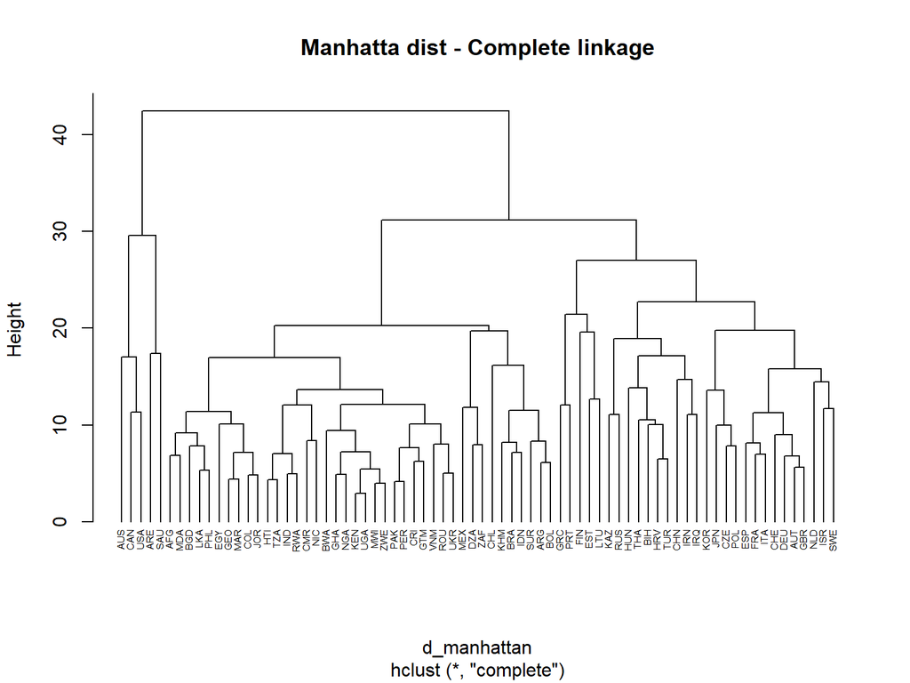

```r
hc <- hclust(d_manhattan)
plot(hc ,hang = -1, main="Manhatta dist - Complete linkage", cex=0.5)
```

# k-means

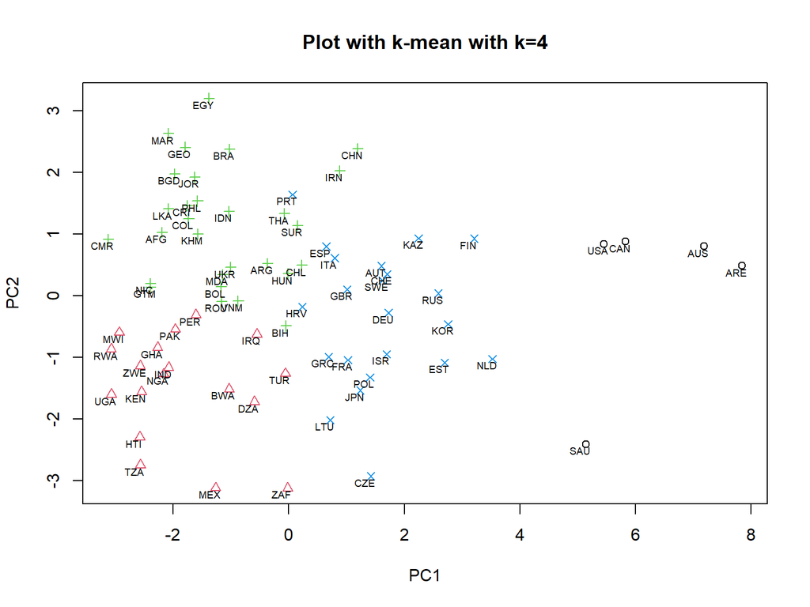

```r
pc <- prcomp(Xs)$x
km1 <- kmeans(Xs, centers = 4 )
km2 <- kmeans(Xs, centers = 5 )

clus1 <- km1$cluster
clus2 <- km2$cluster

plot(pc[,1],pc[,2],col=clus1,pch=clus1,xlab='PC1',ylab='PC2',main="Plot with k-mean with k=4")
text(pc[,1]-0.1,pc[,2]-0.1, labels=rownames(X), cex=0.6)
```

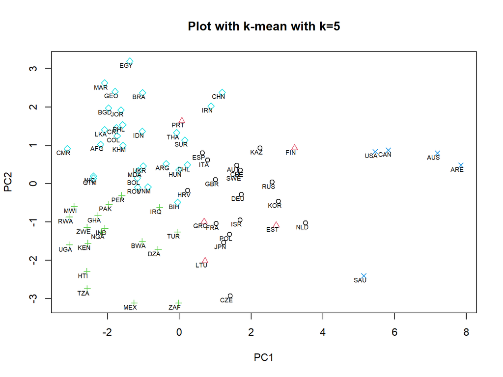

```r
plot(pc[,1],pc[,2],col=clus2,pch=clus2,xlab='PC1',ylab='PC2',main="Plot with k-mean with k=5")
text(pc[,1]-0.1,pc[,2]-0.1, labels=rownames(X), cex=0.6)
```

# Choosing k formally

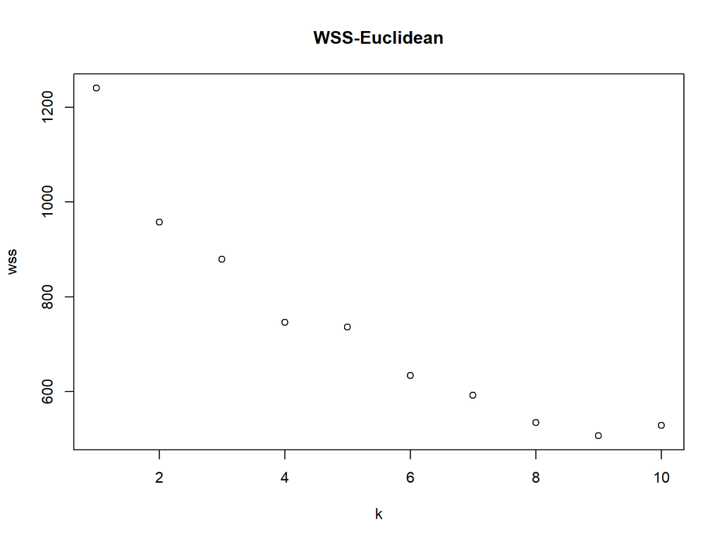

```r
wss = c(sum(Xs^2))

for (i in 2:10) {
  km  = kmeans(Xs, centers = i)
  wss = c(wss,sum(km$withinss))
}
plot(wss,xlab="k",ylab="wss",main="WSS-Euclidean")
```

# With the subset

Distances

```r
d_euclideans <- dist(Xssub)
d_manhattans <- dist(Xssub, method="manhattan")

# S^(-1/2)
Sinvsqrts = Vs%*%diag(1/sqrt(ls))

# X in mahalanobis space
Xinvsqrts = Xssub%*%Sinvsqrts

d_mahalanobiss <- as.dist(dist(Xinvsqrts))
```

Hierarchical Clustering Eucledian

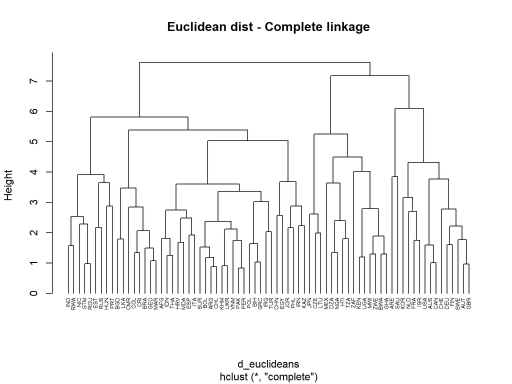

```r
hcs <- hclust(d_euclideans)
plot(hcs ,hang = -1, main="Euclidean dist - Complete linkage", cex=0.5)
```

Manhattan

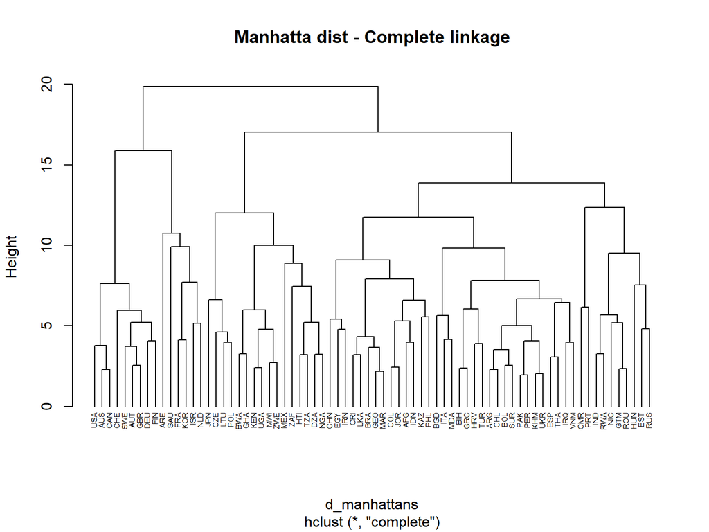

```r
hcs <- hclust(d_manhattans)
plot(hcs ,hang = -1, main="Manhatta dist - Complete linkage", cex=0.5)
```

# k-means

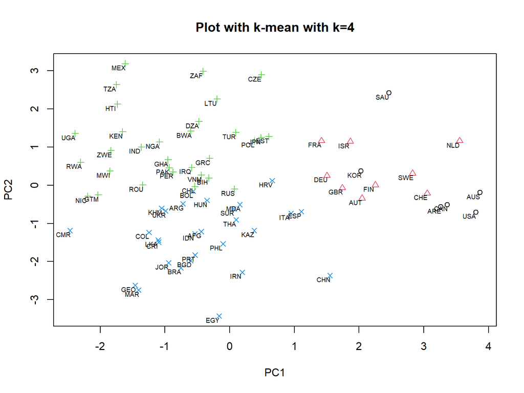

```r
pcs <- prcomp(Xssub)$x
km1s <- kmeans(Xssub, centers = 4 )
km2s <- kmeans(Xssub, centers = 5 )

clus1s <- km1s$cluster
clus2s <- km2s$cluster

plot(pcs[,1],pcs[,2],col=clus1s,pch=clus1s,xlab='PC1',ylab='PC2',main="Plot with k-mean with k=4")
text(pcs[,1]-0.1,pcs[,2]-0.1, labels=rownames(X), cex=0.6)
```

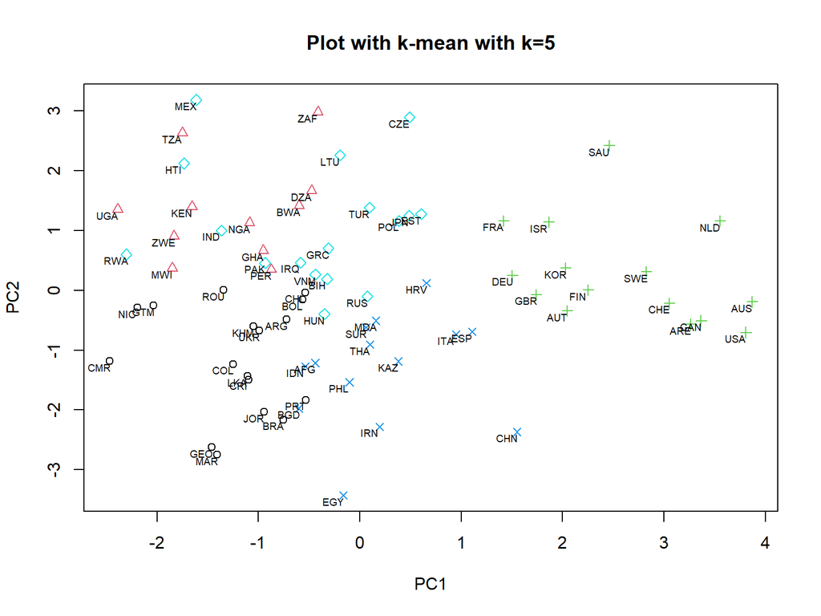

```r
plot(pcs[,1],pcs[,2],col=clus2s,pch=clus2s,xlab='PC1',ylab='PC2',main="Plot with k-mean with k=5")
text(pcs[,1]-0.1,pcs[,2]-0.1, labels=rownames(X), cex=0.6)
```

# Choosing k formally

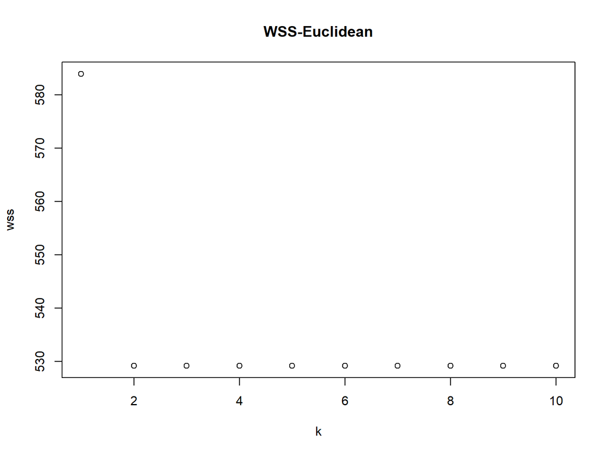

```r
wsssub = c(sum(Xssub^2))

for (i in 2:10) {
  kms  = kmeans(Xssub, centers = i)
  wsssub = c(wsssub,sum(km$withinss))
}
plot(wsssub,xlab="k",ylab="wss",main="WSS-Euclidean")
```

# Further thoughts